# Supervised Learning: Theory and Practice in R

Alejandro Schuler  
2019

```r
library(tidyverse)
```

### What is the question?

- Scientific questions in clinical informatics can be roughly categorized into one of six types
- One project may have more than one type of question
- Similar methods can be used to answer different questions

### What is supervised learning?

- Supervised learning is about estimating \( E[Y|X] \): given that we observe some variables \( X=x \), what should we expect the value of the variable \( Y \) to be? For example:
  - Given that we know the demographics and presenting characteristics of a patient, can we predict what their final diagnosis will be for given visit? (diagnostic model)
  - Given a patient's current LAPS, demographics, and vitals, can we predict whether or not they will transfer to the ICU in 6 hours? (prognostic model)
- We estimate \( E[Y|X] \) from data \( (Y_i, X_i) \) that has been collected
- Supervised learning is also called
  - *regression* if \( Y \) is continuous (linear regression being one example)
  - *classification* if \( Y \) is categorical
  - *prediction* if \( Y \) is something typically measured after \( X \)
- We do not care *why* or *how* \( X \) and \( Y \) are related.
- \( Y \) is alternatively called the *outcome*, *dependent variable*, or *target*
- \( X \) are referred to as the *covariates*, *independent variables*, *predictors*, or *features*

### A note about math and symbols

- \( E[Y|X] \) and other mathematical notations are your friends, not your adversaries
- They are just a shorter way of expressing ideas that would otherwise take a lot of text
- Mathematics was an oral tradition for most of its history!
- If at any point it is not clear what is meant by notation, please speak up

### Exercise: supervised learning?

Which of these is a supervised learning problem and which is not?

- Estimating the incidence of kidney disease in the bay area
- Finding patients with a mention of type 2 diabetes in their record
- Finding groups of patients that are more similar to each other than they are to patients outside the group
- Estimating the risk that a hypertensive patient will have a heart attack in the next three months
- Estimating how long it will take for a patient's wound to heal
- Estimating the effect of a heart surgery on 30-day survival

### The data-generating process (DGP)

- The true model is the real process that generates the data. We imagine that the data are drawn from an unknown probability distribution over the covariates and outcome \( (X_i,Y_i) \overset{IID}{\sim} \mathcal{D}(X,Y) \)
  - Here, \( \mathcal{D}(X,Y) \) is the data-generating process (true model)
  - If we knew what this was, we would know everything there is to know about the relationship between \( X \) and \( Y \)
- In reality, we can never completely pin this down, but we assume the universe generates the data *somehow* and there is *some* “real” distribution \( \mathcal{D} \) the the data are “drawn from”

### An example DGP

- In this universe, assume \( X \) (e.g. patient age in some population) and \( Y \) (e.g. patient COPS2 in that population) are generated via \( (X,Y) \sim \mathcal{N}(\mathbf{\mu}, \mathbf{\Sigma}) \)

```r
> library(MASS) # for mvrnorm

Attaching package: 'MASS'
The following object is masked from 'package:dplyr':

    select
>
> Sigma = rbind(c(5,4),
+               c(4,7))
> mu = c(63, 40)
>
> mvrnorm(5, mu, Sigma) %>%
+   as_tibble() %>%
+   set_names(c("x","y"))
Warning: `as_tibble.matrix()` requires a matrix with column names or a `.name_repair` argument. Using compatibility `.name_repair`.
This warning is displayed once per session.
# A tibble: 5 x 2
      x     y
  <dbl> <dbl>
1  62.7  37.7
2  62.8  40.9
3  60.6  38.5
4  65.5  44.5
5  64.0  40.6
```

### An example DGP

- We've just generated data!
- In real life, we don't get to see the “code” that made the data, we just get the data itself:

```
# A tibble: 5 x 2
      x     y
  <dbl> <dbl>
1  62.7  37.7
2  62.8  40.9
3  60.6  38.5
4  65.5  44.5
5  64.0  40.6
```

- When we talk about the DGP (or “true model”), we're talking about the unknown “code” that made our data
- The notation we use is \( (X_i,Y_i) \overset{IID}{\sim} \mathcal{D}(X,Y) \).
  - \( (X,Y) \) represent the data we might draw, \( \mathcal{D}(X,Y) \) is the code that it gets drawn from. IID (independent and identically distributed) means that the code is the same each time we run it

### An example DGP

Let's generate 10000 samples

```r
> data = mvrnorm(10000, mu, Sigma) %>%
+   as_tibble() %>%
+   set_names(c("x","y"))
```

### An example DGP: conditional mean

- If \( (X,Y) \sim \mathcal{N}(\mathbf{\mu}, \mathbf{\Sigma}) \), we can do some math to figure out that \( E[Y|X=x] = \mu_Y + \sigma_{XY} \sigma_{X}^{-1} (x-\mu_X) \), where

\( \mathbf{\mu} = \left[ \begin{array}{c} \mu_X \\ \mu_Y \end{array} \right] \) \( \mathbf{\Sigma} = \left[ \begin{array}{cc} \sigma_{X} & \sigma_{XY} \\ \sigma_{XY} & \sigma_{Y} \end{array} \right] \)

```r
> Sigma = rbind(c(5,4),
+               c(4,7))
> mu = c(63, 40)
>
> names(mu) = c("x", "y")
> rownames(Sigma) = c("x","y")
> colnames(Sigma) = c("x","y")
>
> # ----> math ----->
> E_y_given_x = function(x){
+   mu["y"] + (Sigma["x","y"] / Sigma["x","x"]) * (x-mu["x"])
+ }
```

### An example DGP: visualizing samples and a conditional mean

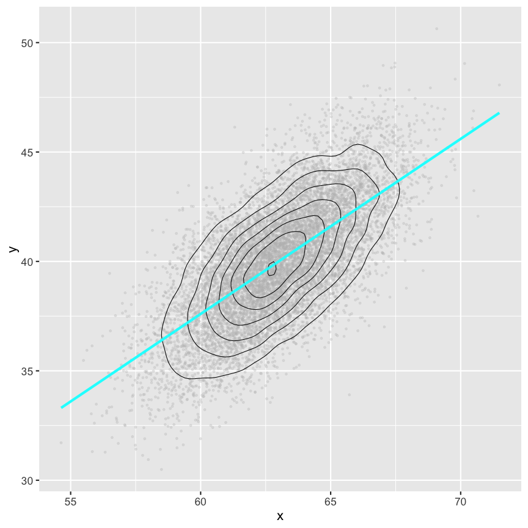

```r
> data %>%
+   mutate(E_y_given_x = E_y_given_x(x)) %>%
+ ggplot(aes(x=x, y=y)) +
+   geom_point(alpha=0.3, color="grey") +
+   geom_density2d(color="black") +
+   geom_line(aes(y=E_y_given_x), color="cyan", size=2)
```

### An example DGP: visualizing samples and a conditional mean

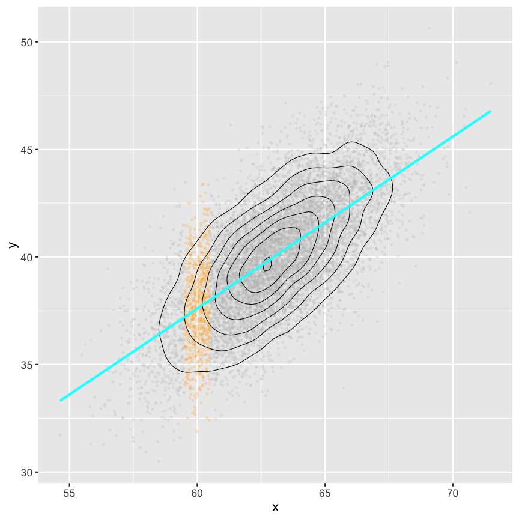

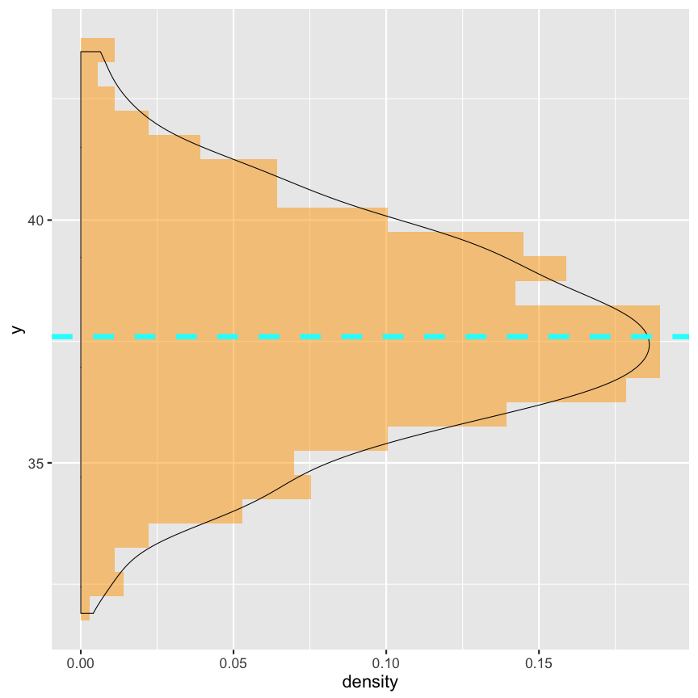

### An example DGP: visualizing samples and a conditional mean

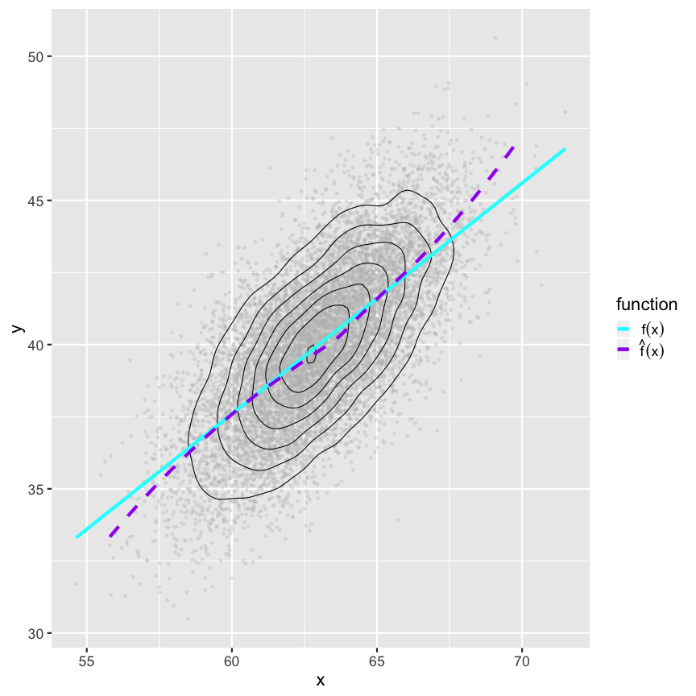

- In supervised learning, we're interested in approximating this cyan function which we call \( f(x) = E[Y|X=x] \)
- We'll say \( \hat{f}(x) \) is an approximation of \( f \) that we come up with using the data
- The goals of supervised learning are:
  1. Come up with a good estimate \( \hat{f} \)\( (x) \) (*learning*)
  2. Figure out how good that estimate is (*evaluating*)